# Popular cars in Massachusetts

2018-09-25

There were 4,571,544 private passenger cars and light-trucks registered in Massachusetts in 2018, according to data from the state Registry of Motor Vehicles.

We used the data for a [Boston Globe story](https://apps.bostonglobe.com/metro/graphics/2018/09/cars-by-town/). Billy wrote the story. I analyzed the data. And Patrick Garvin created the graphics on the Boston Globe site.

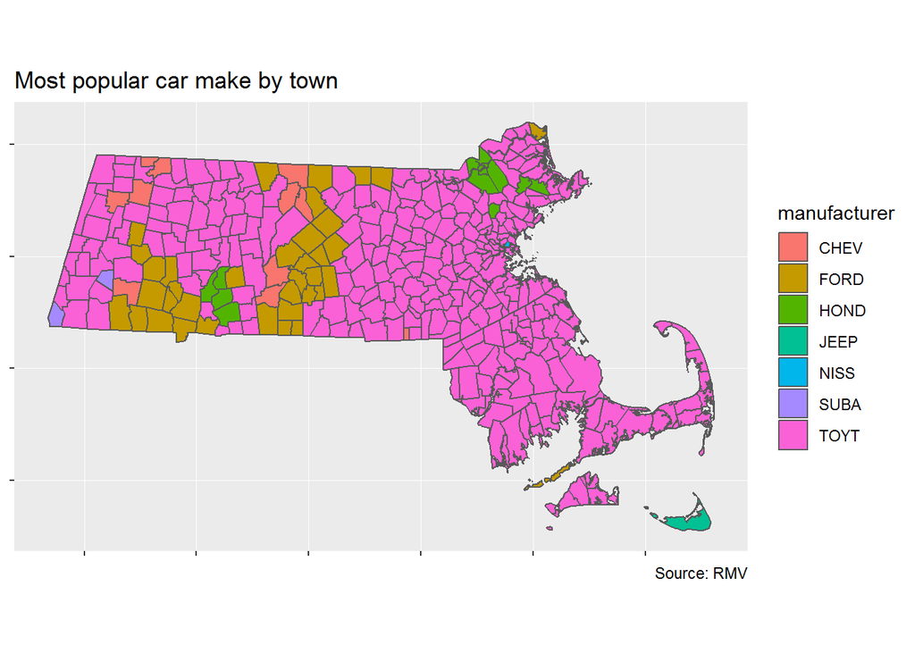

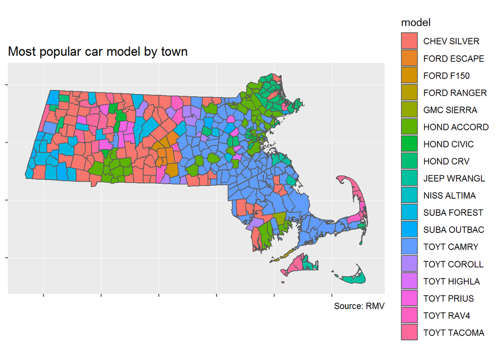

The most popular car in Nantucket is JEEP WRANGL.

The top 10 cars in Boston are:

| model | percent | rank |
| --- | --- | --- |
| HOND ACCORD | 4.22 | 1 |
| TOYT CAMRY | 4.14 | 2 |
| TOYT COROLL | 3.49 | 3 |
| HOND CIVIC | 3.34 | 4 |
| TOYT RAV4 | 3.06 | 5 |
| HOND CRV | 2.78 | 6 |
| NISS ALTIMA | 1.93 | 7 |
| TOYT HIGHLA | 1.58 | 8 |
| NISS ROGUE | 1.51 | 9 |
| SUBA FOREST | 1.18 | 10 |

The top 10 cars in Revere are:

| model | percent | rank |
| --- | --- | --- |
| HOND ACCORD | 4.56 | 1 |
| TOYT CAMRY | 4.13 | 2 |
| TOYT COROLL | 3.99 | 3 |
| HOND CIVIC | 3.83 | 4 |
| TOYT RAV4 | 3.48 | 5 |
| HOND CRV | 2.74 | 6 |
| NISS ALTIMA | 2.34 | 7 |
| NISS ROGUE | 1.91 | 8 |
| TOYT HIGHLA | 1.40 | 9 |
| HOND PILOT | 1.30 | 10 |

The top 3 makes in Boston are

| manufacturer | percent | rank |
| --- | --- | --- |
| TOYT | 19.52 | 1 |
| HOND | 14.37 | 2 |
| FORD | 7.62 | 3 |

There are 35 Ferraris registered in Boston. There are also 55 Plymouths, including 2 Plymouth Valients.

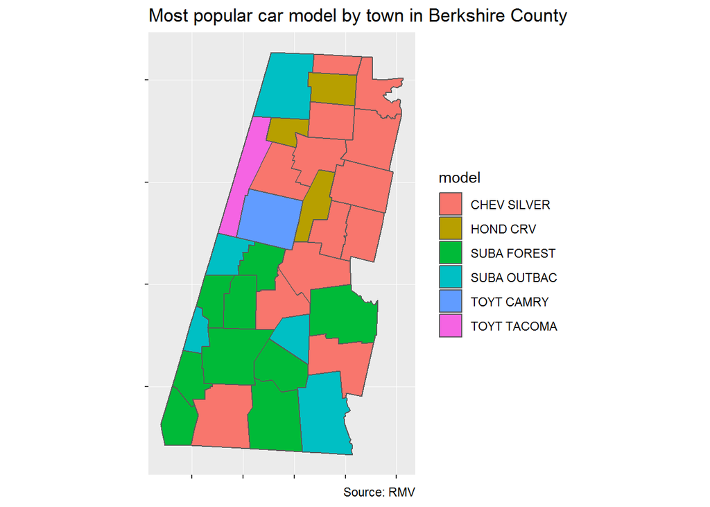

These are the Berkshire County towns where the Chevrolet Silverado is tops: ADAMS, CHESHIRE, CLARKSBURG, FLORIDA, HINSDALE, LANESBOROUGH, LEE, OTIS, PERU, SAVOY, SHEFFIELD, WASHINGTON, WINDSOR

These are the Berkshire County towns where the Subaru Forrester is tops: BECKET, EGREMONT, GREAT BARRINGTON, LENOX, MONTEREY, MOUNT WASHINGTON, NEW MARLBOROUGH, STOCKBRIDGE, WEST STOCKBRIDGE

These are the Berkshire County towns where the Subaru Outback is tops: ALFORD, RICHMOND, SANDISFIELD, TYRINGHAM, WILLIAMSTOWN

These are number of towns where Subaru Forrester is tops: 20

And these are the cars that dominate specific cars:

| city | model | total | percent |
| --- | --- | --- | --- |
| NANTUCKET | JEEP WRANGL | 1597 | 11.41 |
| LAWRENCE | HOND ACCORD | 3760 | 9.73 |
| PERU | CHEV SILVER | 58 | 8.10 |

In, NANTUCKET, the JEEP WRANGL dominates, accounting for 11.41 of the town’s cars.

Close behind in LAWRENCE, the HOND ACCORD makes up 9.73 of the city’s vehicles.

These models are popular in lots of towns

| model | number_of_towns |
| --- | --- |
| TOYT CAMRY | 112 |
| CHEV SILVER | 70 |
| HOND ACCORD | 43 |
| HOND CRV | 28 |
| SUBA FOREST | 20 |
| TOYT TACOMA | 19 |

Here are towns where one manufacturer dominates:

| city | manufacturer | total | percent | rank |
| --- | --- | --- | --- | --- |
| LAWRENCE | HOND | 11840 | 30.65 | 1 |
| WELLFLEET | TOYT | 860 | 27.52 | 1 |
| EASTHAM | TOYT | 1353 | 26.94 | 1 |
| ORLEANS | TOYT | 1664 | 26.02 | 1 |

Here are the top manufacturers statewide:

| manufacturer | total | percent | rank |
| --- | --- | --- | --- |
| TOYT | 809944 | 17.717078 | 1 |
| HOND | 575652 | 12.592070 | 2 |
| FORD | 461552 | 10.096195 | 3 |
| CHEV | 351605 | 7.691165 | 4 |
| NISS | 283560 | 6.202718 | 5 |
| JEEP | 234502 | 5.129602 | 6 |
| SUBA | 221059 | 4.835543 | 7 |
| HYUN | 160020 | 3.500349 | 8 |
| DODG | 112873 | 2.469034 | 9 |
| BMW | 111271 | 2.433992 | 10 |

Here are the top models statewide:

| model | total | percent | rank |
| --- | --- | --- | --- |
| TOYT CAMRY | 161458 | 3.531805 | 1 |
| HOND ACCORD | 147750 | 3.231950 | 2 |
| TOYT COROLL | 129578 | 2.834447 | 3 |
| HOND CIVIC | 121300 | 2.653370 | 4 |
| HOND CRV | 119028 | 2.603672 | 5 |
| TOYT RAV4 | 113585 | 2.484609 | 6 |
| CHEV SILVER | 72885 | 1.594319 | 7 |
| NISS ALTIMA | 72332 | 1.582223 | 8 |
| TOYT HIGHLA | 66890 | 1.463182 | 9 |
| SUBA FOREST | 66709 | 1.459223 | 10 |

These are the towns where the Toyota Tacoma is the popular vehicle: AQUINNAH, ASHFIELD, BUCKLAND, CHARLEMONT, CHILMARK, CONWAY, ESSEX, GOSHEN, HANCOCK, LEYDEN, ORLEANS, PROVINCETOWN, TISBURY, TRURO, WELLFLEET, WEST TISBURY, WESTHAMPTON, WHATELY, WORTHINGTON

The Toyota Prius is the most popular car in 9 towns: AMHERST, CARLISLE, LEVERETT, LINCOLN, NORTHAMPTON, PELHAM, PLAINFIELD, SHELBURNE, SHUTESBURY

Here are the top five most popular cars in Cambridge:

| model | percent | rank |
| --- | --- | --- |
| HOND CIVIC | 4.83 | 1 |
| HOND ACCORD | 3.93 | 2 |
| HOND CRV | 3.67 | 3 |
| TOYT PRIUS | 3.65 | 4 |
| TOYT CAMRY | 3.60 | 5 |

And here are the top 10 most popular cars in Weston

| model | total | percent | rank |
| --- | --- | --- | --- |
| HOND CRV | 181 | 2.00 | 1 |
| JEEP WRANGL | 173 | 1.91 | 2 |
| BMW X5 | 165 | 1.82 | 3 |
| TOYT SIENNA | 162 | 1.79 | 4 |
| TOYT HIGHLA | 161 | 1.78 | 5 |
| LEXS RX350 | 149 | 1.64 | 6 |
| SUBA OUTBAC | 146 | 1.61 | 7 |
| ACUR MDX | 141 | 1.56 | 8 |
| HOND ACCORD | 141 | 1.56 | 9 |
| AUDI Q5 | 136 | 1.50 | 10 |

[output not shown]

Here are the top five towns for BMWs:

| city | percent | rank |
| --- | --- | --- |
| WESTON | 8.83 | 3 |
| DOVER | 8.18 | 3 |
| WELLESLEY | 7.67 | 3 |
| SUDBURY | 7.66 | 3 |
| MANCHESTER | 7.51 | 4 |

Here are the top 10 towns for Tesla:

| city | total | percent | rank |
| --- | --- | --- | --- |
| WESTON | 125 | 1.38 | 18 |
| DOVER | 44 | 0.88 | 21 |
| WELLESLEY | 136 | 0.72 | 21 |
| LINCOLN | 33 | 0.71 | 23 |
| CARLISLE | 27 | 0.60 | 27 |
| CONCORD | 72 | 0.54 | 28 |
| SHERBORN | 19 | 0.53 | 27 |
| BROOKLINE | 127 | 0.49 | 24 |
| LEXINGTON | 112 | 0.48 | 28 |
| WAYLAND | 50 | 0.46 | 29 |